# Lecture 5: Data wrangling

EC7412 Part II: Data Science for Economists

Adam Altmejd Selder

adam.altmejd@sofi.su.se

Swedish Institute for Social Research (SOFI)

April 25, 2025

# Introduction

- Introduction
- Reading data
- Subsetting / Filtering (i)
- Working with columns (j)
- Grouping and summarizing (by)
- Working with strings and dates
- Merging and reshaping

## The data workflow revisited

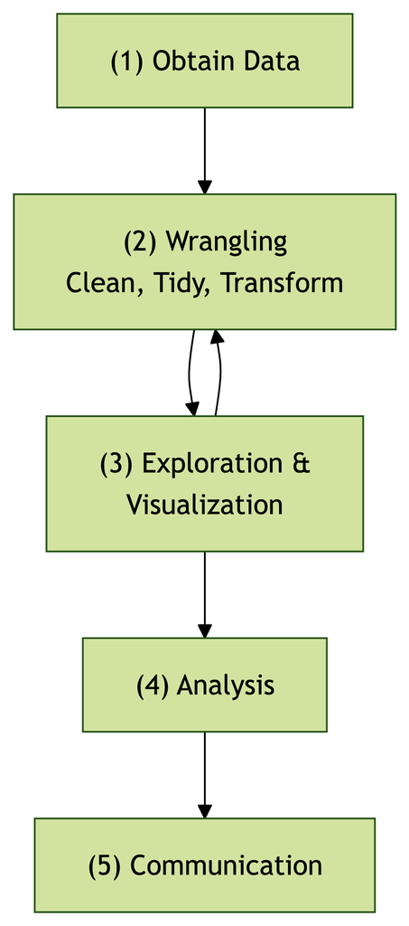

- **Obtain** and import data
- **Wrangling=** make data usable for analysis
  - **Clean** data inconsistensies
  - **Tidy** data format
  - **Transform** data, create variables

## Why is wrangling important?

- Raw data is rarely ready for analysis or visualization
- Errors, inconsistencies, and structural issues can lead to:
  - Incorrect results
  - Wasted time debugging later
  - Difficulty merging or comparing datasets
- Good wrangling practices ensure data quality and make analysis smoother
- *Garbage In, Garbage Out*

## Our r tools: `data.table` and `dplyr`

- Two dominant paradigms for data manipulation in R
- Both are powerful and widely used, but with different syntax
- We will focus on `data.table`, because it is much faster
- Show `dplyr` equivalents for comparison

## `data.table`: Core concept

- An **enhancement** of base R’s `data.frame`
- Designed for **speed** and **memory efficiency**
- Concise, general syntax:

  ```r
  DT[i, j, by]
  ```

  - `DT`: your data.table object
  - `i`: Row filtering (SQL `WHERE`)
  - `j`: Column operations (SQL `SELECT`, `UPDATE`)
  - `by`: Grouping operation (SQL `GROUP BY`)

## `data.table`: Key features

- **Fast:** Operations implemented in C
- **Memory efficient:** Modifies *by reference* using `:=`<sup>1</sup>
- **Indexing:** Automatic indexing (with keys) speeds up subsets and joins
- **Concise syntax:** Combines operations efficiently
[^1]: But this means that when you do not want to edit by reference you have to be explicit and use `copy()`.

## `dplyr`: Core concept

- Part of the **Tidyverse** collection of packages
- Focuses on **readability** and **consistency**
- Uses distinct “verbs” for common operations

## `dplyr`: Key verbs

- `filter()`: Subset rows
- `select()`: Select columns
- `mutate()`: Create/modify columns
- `summarise()` / `summarize()`: Aggregate data
- `group_by()`: Perform operations group-wise
- `arrange()`: Reorder rows

## Example syntax

`data.table`

```r
data[condition,
     .(new_var = mean(old_var)),
     by = "group_var"]
```

`dplyr`

```r
data |>
  filter(condition) |>
  group_by(group_var) |>
  summarise(new_var = mean(old_var))
```

If you really like the `dplyr` syntax but want to take advantage of `data.table` speeds, there is the [dtplyr](https://dtplyr.tidyverse.org/) package which uses data.table as a backend for dplyr-syntax operations.

## Key differences

**`data.table`**

- **Pros:** Speed, memory efficiency, concise syntax, powerful indexing/joins. Ideal for large data.
- **Cons:** Steeper learning curve, syntax less “English-like”, modify-by-reference needs care.

**`dplyr`**

- **Pros:** Highly readable verbs, Tidyverse integration (ggplot2, etc.).
- **Cons:** Slower, uses more memory, especially on large data or complex groups.

# Reading data

- Introduction
- Reading data
- Subsetting / Filtering (i)
- Working with columns (j)
- Grouping and summarizing (by)
- Working with strings and dates
- Merging and reshaping

## `data.table::fread()` for text files

- `fread()` is fast and flexible for delimited text (CSV, TSV)
- Automatically solves many possible data issues
- Let’s try to read some AI-generated data:

```r
dogs = fread("dog_inventory.csv")
```

```r
dogs
```

```
     dog_id     name              breed   age         color   price insured intake_date  sale_date         new owner
      <int>   <char>             <char> <int>        <char>   <num>   <int>      <IDat>     <char>            <char>
  1:     13    Buddy Labrador Retriever     5        Yellow  450.50       1  2023-01-15 03/20-2023        John Smith
  2:   3382     Lucy    German Shepherd     3 Black and tan  600.00       1  2023-02-10 04/01-2023      Maria Garcia
  3:   4200      Max   Golden Retriever     7        Golden  550.75       0  2023-03-05 06/15-2023     James Johnson
 ---
168:   8857    Snowy              Corgi     2  White Fluffy  990.00     -99  2023-12-05 03/06-2024       Lois Barnes
169:    126 Leo King            Whippet     5   Lion Yellow 1010.50       0  2024-01-20
170:   8159      Tut            Whippet     0   Reddish Tan  750.75       1  2024-03-27            Sven \xd6sterberg
```

## Fixing issues: character encoding

- Computers need to encode characters to store them
- Unfortunately there are tons of different encodings
- A-Z, 0-9 is usually the same, but code for e.g. å can vary
- Can create a real mess…

```r
fread("dog_inventory.csv", encoding = "UTF-8", skip = 174, nrows = 1)
```

```
      V1     V2      V3    V4          V5     V6    V7         V8     V9               V10
   <int> <char>  <char> <int>      <char>  <num> <int>     <IDat> <lgcl>            <char>
1:  8159    Tut Whippet     0 Reddish Tan 750.75     1 2024-03-27     NA Sven \xd6sterberg
```

```r
fread("dog_inventory.csv", encoding = "Latin-1", skip = 174, nrows = 1)
```

```
      V1     V2      V3    V4          V5     V6    V7         V8     V9            V10
   <int> <char>  <char> <int>      <char>  <num> <int>     <IDat> <lgcl>         <char>
1:  8159    Tut Whippet     0 Reddish Tan 750.75     1 2024-03-27     NA Sven Österberg
```

## `fread()`: fixing names

```r
dogs = fread("dog_inventory.csv", encoding = "Latin-1")
names(dogs)
```

```
 [1] "dog_id"      "name"        "breed"       "age"         "color"       "price"       "insured"     "intake_date" "sale_date"   "new owner"
```

To refer to a name with a space we need to enclose it with backticks (``)

```r
dogs$`new owner`[5]
```

```
[1] "Kenji Tanaka"
```

`check.names=TRUE` fixes column names automatically

```r
names(fread("dog_inventory.csv", check.names = TRUE))[10]
```

```
[1] "new.owner"
```

## `fread()`: coding missing data

```r
unique(dogs$insured)
```

```
[1]   1   0  NA -99
```

`na.strings` argument takes vector of strings that should be coded as `NA`

```r
dogs = fread("dog_inventory.csv",
             encoding = "Latin-1",
             check.names = TRUE,
             colClasses = c(dog_id = "character"),
             na.strings = c("", "-99"))
```

## `fread()`: selecting columns

Use `select` to read a subset of columns

```r
fread("dog_inventory.csv",
      select = c("dog_id", "name", "breed"))
```

```
     dog_id     name              breed
      <int>   <char>             <char>
  1:     13    Buddy Labrador Retriever
  2:   3382     Lucy    German Shepherd
  3:   4200      Max   Golden Retriever
 ---
168:   8857    Snowy              Corgi
169:    126 Leo King            Whippet
170:   8159      Tut            Whippet
```

## `fread()`: specifying types

`fread()` tries to guess the data types

- override auto-detection for problematic columns with `colClasses`:

```r
fread("dog_inventory.csv",
      select = c("dog_id", "name", "breed"),
      colClasses = c(dog_id = "character"))
```

```
     dog_id     name              breed
     <char>   <char>             <char>
  1:   0013    Buddy Labrador Retriever
  2:   3382     Lucy    German Shepherd
  3:   4200      Max   Golden Retriever
 ---
168:   8857    Snowy              Corgi
169:   0126 Leo King            Whippet
170:   8159      Tut            Whippet
```

You can also use `select` to both chose columns and specify types by supplying a named vector, see `?fread`.

## Reading directly from urls

`fread()` handles reading text files directly from the web

```r
fread("https://github.com/adamaltmejd/datascience-course/raw/refs/heads/main/lectures/lecture_5/dog_inventory.csv")
```

```
     dog_id     name              breed   age         color   price insured intake_date  sale_date         new owner
      <int>   <char>             <char> <int>        <char>   <num>   <int>      <IDat>     <char>            <char>
  1:     13    Buddy Labrador Retriever     5        Yellow  450.50       1  2023-01-15 03/20-2023        John Smith
  2:   3382     Lucy    German Shepherd     3 Black and tan  600.00       1  2023-02-10 04/01-2023      Maria Garcia
  3:   4200      Max   Golden Retriever     7        Golden  550.75       0  2023-03-05 06/15-2023     James Johnson
 ---
168:   8857    Snowy              Corgi     2  White Fluffy  990.00     -99  2023-12-05 03/06-2024       Lois Barnes
169:    126 Leo King            Whippet     5   Lion Yellow 1010.50       0  2024-01-20
170:   8159      Tut            Whippet     0   Reddish Tan  750.75       1  2024-03-27            Sven \xd6sterberg
```

## Importing Stata `.dta` files with `haven`

- Use `haven::read_dta()`. Preserves Stata labels.
- Convert to `data.table` with `as.data.table()`,
- Set value labels with `as_factors()`

```r
library(haven)

stata_dt = read_dta("path/to/stata_file.dta") |>
  as.data.table()

stata_dt[, factor_variable := as_factor(labelled_variable)]
```

Similarly, we would use `haven::write_dta()` to save a data frame as a Stata dta file.

## Reading excel files with `readxl`

```r
library(readxl)
excel_dt = read_excel("path/to/spreadsheet.xlsx")
```

`readxl` supports selecting sheets:

```r
excel_sheets("path/to/spreadsheet.xlsx")
read_excel("spreadsheet.xlsx", sheet = "Sheet2")
```

and even specific ranges:

```r
read_excel("spreadsheet.xlsx", range = "A1:D10", skip = 2)
```

# Subsetting / Filtering (i)

- Introduction
- Reading data
- Subsetting / Filtering (i)
- Working with columns (j)
- Grouping and summarizing (by)
- Working with strings and dates
- Merging and reshaping

## Subsetting / Filtering

`DT[condition, ...]` and `dplyr::filter(condition)` subsets rows based on `condition`.

Selecting dogs aged less than 0:

- `data.table`
- `dplyr`

```r
dogs[age < 0]
```

```
   dog_id    name           breed   age           color  price insured intake_date  sale_date        new.owner
   <char>  <char>          <char> <int>          <char>  <num>   <int>      <IDat>     <char>           <char>
1:   6455    Coco  French Bulldog    -1         Brindle  950.0       1  2023-06-12 08/15-2023   Emil Jørgensen
2:   6859  Härley       Dalmatian    -3 White and black  740.5       1  2023-10-04 01/07-2024    Elbieta Nowak
3:   4967    Növa Irish Wolfhound    -2            Gray 1100.0       1  2024-01-06       <NA>             <NA>
4:   6301 Düke II    Afghan Hound    -4          Golden  820.0       1  2023-04-29 07/02-2023 Héloïse Lefebvre
5:   5131     Rex       Dachshund    -2   Black and tan  630.0       1  2023-05-29 08/07-2023   David Anderson
6:   7690  Wolfie Irish Wolfhound    -5         Wheaten 1120.0       1  2023-09-27 12/31-2023    Victor Hughes
```

```r
filter(dogs, age < 0)
```

```
   dog_id    name           breed   age           color  price insured intake_date  sale_date        new.owner
   <char>  <char>          <char> <int>          <char>  <num>   <int>      <IDat>     <char>           <char>
1:   6455    Coco  French Bulldog    -1         Brindle  950.0       1  2023-06-12 08/15-2023   Emil Jørgensen
2:   6859  Härley       Dalmatian    -3 White and black  740.5       1  2023-10-04 01/07-2024    Elbieta Nowak
3:   4967    Növa Irish Wolfhound    -2            Gray 1100.0       1  2024-01-06       <NA>             <NA>
4:   6301 Düke II    Afghan Hound    -4          Golden  820.0       1  2023-04-29 07/02-2023 Héloïse Lefebvre
5:   5131     Rex       Dachshund    -2   Black and tan  630.0       1  2023-05-29 08/07-2023   David Anderson
6:   7690  Wolfie Irish Wolfhound    -5         Wheaten 1120.0       1  2023-09-27 12/31-2023    Victor Hughes
```

## Subsetting / Filtering (cont.)

Selecting insured unsold dogs:

- `data.table`
- `dplyr`

```r
dogs[insured == 1 & is.na(sale_date)]
```

```
    dog_id    name               breed   age           color   price insured intake_date sale_date      new.owner
    <char>  <char>              <char> <int>          <char>   <num>   <int>      <IDat>    <char>         <char>
 1:   6988    Bear               Boxer     6            Rust  900.00       1  2024-01-25      <NA>           <NA>
 2:   8774    Duke    Golden Retriever     5           White  850.00       1  2024-03-10      <NA>           <NA>
 3:   8853 Winston           Dalmatian     5 Liver and white  550.00       1  2024-01-02      <NA>           <NA>
---
19:   1048  Rascal Jack Russel Terrier     6     Broken Coat  510.00       1  2024-03-29      <NA>           <NA>
20:   2977   Major                 Pug     4         Brindle 1020.75       1  2024-02-21      <NA>           <NA>
21:   8159     Tut             Whippet     0     Reddish Tan  750.75       1  2024-03-27      <NA> Sven Österberg
```

```r
filter(dogs, insured == 1 & is.na(sale_date))
```

```
    dog_id    name               breed   age           color   price insured intake_date sale_date      new.owner
    <char>  <char>              <char> <int>          <char>   <num>   <int>      <IDat>    <char>         <char>
 1:   6988    Bear               Boxer     6            Rust  900.00       1  2024-01-25      <NA>           <NA>
 2:   8774    Duke    Golden Retriever     5           White  850.00       1  2024-03-10      <NA>           <NA>
 3:   8853 Winston           Dalmatian     5 Liver and white  550.00       1  2024-01-02      <NA>           <NA>
---
19:   1048  Rascal Jack Russel Terrier     6     Broken Coat  510.00       1  2024-03-29      <NA>           <NA>
20:   2977   Major                 Pug     4         Brindle 1020.75       1  2024-02-21      <NA>           <NA>
21:   8159     Tut             Whippet     0     Reddish Tan  750.75       1  2024-03-27      <NA> Sven Österberg
```

## Selecting using row numbers

Select first and last row (note `.N` and `row_number()`):

- `data.table`
- `dplyr`

```r
dogs[c(1,.N)]
```

```
   dog_id   name              breed   age       color  price insured intake_date  sale_date      new.owner
   <char> <char>             <char> <int>      <char>  <num>   <int>      <IDat>     <char>         <char>
1:   0013  Buddy Labrador Retriever     5      Yellow 450.50       1  2023-01-15 03/20-2023     John Smith
2:   8159    Tut            Whippet     0 Reddish Tan 750.75       1  2024-03-27       <NA> Sven Österberg
```

```r
filter(dogs, row_number() %in% c(1, n()))
```

```
   dog_id   name              breed   age       color  price insured intake_date  sale_date      new.owner
   <char> <char>             <char> <int>      <char>  <num>   <int>      <IDat>     <char>         <char>
1:   0013  Buddy Labrador Retriever     5      Yellow 450.50       1  2023-01-15 03/20-2023     John Smith
2:   8159    Tut            Whippet     0 Reddish Tan 750.75       1  2024-03-27       <NA> Sven Österberg
```

- `data.table`
- `dplyr`

```r
dogs[1:(.N-11)]
```

```
     dog_id   name                    breed   age           color  price insured intake_date  sale_date     new.owner
     <char> <char>                   <char> <int>          <char>  <num>   <int>      <IDat>     <char>        <char>
  1:   0013  Buddy       Labrador Retriever     5          Yellow 450.50       1  2023-01-15 03/20-2023    John Smith
  2:   3382   Lucy          German Shepherd     3   Black and tan 600.00       1  2023-02-10 04/01-2023  Maria Garcia
  3:   4200    Max         Golden Retriever     7          Golden 550.75       0  2023-03-05 06/15-2023 James Johnson
 ---
157:   4890 Anubis                   Beagle     1 Black and white 710.00      NA  2024-01-17       <NA>          <NA>
158:   4104 Chewie             Bull Terrier     9           Beige 570.75       0  2024-02-29       <NA>          <NA>
159:   2625  Drake Chesapeake Bay Retriever     5           Sedge 740.00       1  2023-03-08 05/12-2023     Randy Cox
```

```r
filter(dogs, row_number() < n()-10)
```

```
     dog_id   name                    breed   age           color  price insured intake_date  sale_date     new.owner
     <char> <char>                   <char> <int>          <char>  <num>   <int>      <IDat>     <char>        <char>
  1:   0013  Buddy       Labrador Retriever     5          Yellow 450.50       1  2023-01-15 03/20-2023    John Smith
  2:   3382   Lucy          German Shepherd     3   Black and tan 600.00       1  2023-02-10 04/01-2023  Maria Garcia
  3:   4200    Max         Golden Retriever     7          Golden 550.75       0  2023-03-05 06/15-2023 James Johnson
 ---
157:   4890 Anubis                   Beagle     1 Black and white 710.00      NA  2024-01-17       <NA>          <NA>
158:   4104 Chewie             Bull Terrier     9           Beige 570.75       0  2024-02-29       <NA>          <NA>
159:   2625  Drake Chesapeake Bay Retriever     5           Sedge 740.00       1  2023-03-08 05/12-2023     Randy Cox
```

# Working with columns (j)

- Introduction
- Reading data
- Subsetting / Filtering (i)
- Working with columns (j)
- Grouping and summarizing (by)
- Working with strings and dates
- Merging and reshaping

## Working with columns (j)

- `data.table` syntax `DT[i, j, by]`: operates on columns with `j`.
- Use `.()` or `list()` to output a new data.table.
- `dplyr::select()` works similarly
- `data.table`
- `dplyr`

```r
dogs[, .(name)]
```

```
         name
       <char>
  1:    Buddy
  2:     Lucy
  3:      Max
 ---
168:    Snowy
169: Leo King
170:      Tut
```

```r
select(dogs, name)
```

```
         name
       <char>
  1:    Buddy
  2:     Lucy
  3:      Max
 ---
168:    Snowy
169: Leo King
170:      Tut
```

## Excluding columns

- `data.table`
- `dplyr`

```r
dogs[, !c("sale_date", "new.owner")]
```

```
     dog_id     name              breed   age         color   price insured intake_date
     <char>   <char>             <char> <int>        <char>   <num>   <int>      <IDat>
  1:   0013    Buddy Labrador Retriever     5        Yellow  450.50       1  2023-01-15
  2:   3382     Lucy    German Shepherd     3 Black and tan  600.00       1  2023-02-10
  3:   4200      Max   Golden Retriever     7        Golden  550.75       0  2023-03-05
 ---
168:   8857    Snowy              Corgi     2  White Fluffy  990.00      NA  2023-12-05
169:   0126 Leo King            Whippet     5   Lion Yellow 1010.50       0  2024-01-20
170:   8159      Tut            Whippet     0   Reddish Tan  750.75       1  2024-03-27
```

```r
select(dogs, !c(sale_date, new.owner))
```

```
     dog_id     name              breed   age         color   price insured intake_date
     <char>   <char>             <char> <int>        <char>   <num>   <int>      <IDat>
  1:   0013    Buddy Labrador Retriever     5        Yellow  450.50       1  2023-01-15
  2:   3382     Lucy    German Shepherd     3 Black and tan  600.00       1  2023-02-10
  3:   4200      Max   Golden Retriever     7        Golden  550.75       0  2023-03-05
 ---
168:   8857    Snowy              Corgi     2  White Fluffy  990.00      NA  2023-12-05
169:   0126 Leo King            Whippet     5   Lion Yellow 1010.50       0  2024-01-20
170:   8159      Tut            Whippet     0   Reddish Tan  750.75       1  2024-03-27
```

## `data.table` assignment by reference (`:=`)

- Normally to edit a column, R copies the whole dataset in memory
- But `:=` modifies `DT` **in place**
- `data.table`
- `dplyr`

```r
dogs[, price := price * 10]
```

```r
dogs = mutate(dogs, price = price / 10)
```

`copy(DT)` first if you *want* to work with a copy of `DT`

## Removing a column by reference

To delete a `data.table` column, assign it to `NULL`.

```r
dogs[, new.owner := NULL]
```

## Conditional modification with `:=`

- Combine row selection (`i`) with assignment (`j`) for conditional modification in `data.table`
- Here is where data.table is starting to shine
- `data.table`
- `dplyr`

```r
dogs[age < 0, age := NA]
```

```r
dogs = mutate(dogs, age = if_else(age < 0, NA, age))
```

Changing the content of a column in dplyr is always done on a copy, so we need to reassign it for the change to stay.

# Grouping and summarizing (by)

- Introduction
- Reading data
- Subsetting / Filtering (i)
- Working with columns (j)
- Grouping and summarizing (by)
- Working with strings and dates
- Merging and reshaping

## Grouping and summarizing

- `DT[i, j, by = ...]` performs operation `j` separetely by group
- Corresponds to `dplyr::group_by() |> ...`
- `data.table`
- `dplyr`

```r
dogs[, mean(price), by = .(insured)]
```

```
   insured       V1
     <int>    <num>
1:       1 737.5800
2:       0 651.2295
3:      NA 810.1875
```

```r
dogs |>
  group_by(insured) |>
  summarize(mean(price))
```

```
# A tibble: 3 × 2
  insured `mean(price)`
    <int>         <dbl>
1       0          651.
2       1          738.
3      NA          810.
```

## Grouping and summarizing (cont.)

Can group by multiple variables, and by conditions:

- `data.table`
- `dplyr`

```r
dogs[, mean(price), by = .(insured, color == "White")]
```

```
   insured  color       V1
     <int> <lgcl>    <num>
1:       1  FALSE 738.0282
2:       0  FALSE 651.4461
3:       1   TRUE 733.7500
4:       0   TRUE 650.1250
5:      NA   TRUE 590.7500
6:      NA  FALSE 883.3333
```

```r
dogs |>
  group_by(insured, color == "White") |>
  summarize(mean(price))
```

```
# A tibble: 6 × 3
# Groups:   insured [3]
  insured `color == "White"` `mean(price)`
    <int> <lgl>                      <dbl>
1       0 FALSE                       651.
2       0 TRUE                        650.
3       1 FALSE                       738.
4       1 TRUE                        734.
5      NA FALSE                       883.
6      NA TRUE                        591.
```

## `.SD`

Inside a `data.table`, `.SD` refers to the **S**ubset of **D**ata for each group.

We can use this to run more complex operations, like

```r
dogs[, lapply(.SD, func), by = ...]
```

applying a custom function `func` to each `.SD` group.

`.SD` is also a data.table

## `.SDcols`

Specifies the columns included in `.SD`. Can be used to select columns in smart ways.

The `dplyr` solution is simpler though (if you know the verb).

- `data.table`
- `dplyr`

```r
dogs[, .SD, .SDcols = patterns("_date")]
```

```
     intake_date  sale_date
          <IDat>     <char>
  1:  2023-01-15 03/20-2023
  2:  2023-02-10 04/01-2023
  3:  2023-03-05 06/15-2023
 ---
168:  2023-12-05 03/06-2024
169:  2024-01-20       <NA>
170:  2024-03-27       <NA>
```

```r
select(dogs, ends_with("_date"))
```

```
     intake_date  sale_date
          <IDat>     <char>
  1:  2023-01-15 03/20-2023
  2:  2023-02-10 04/01-2023
  3:  2023-03-05 06/15-2023
 ---
168:  2023-12-05 03/06-2024
169:  2024-01-20       <NA>
170:  2024-03-27       <NA>
```

`patterns()` filters by *regular expression*

## Save grouped summaries to column

Saving the average price by age to a new column, repeating the summary for each row in group:

- `data.table`
- `dplyr`

```r
dogs[,
     avg_price_by_age := mean(price),
     by = .(age)]
```

```r
dogs_new = dogs |>
  group_by(age) |>
  mutate(avg_price_by_age = mean(price))
```

```r
dogs[order(age),
     .(age, avg_price_by_age)]
```

```
       age avg_price_by_age
     <int>            <num>
  1:     0         650.4167
  2:     0         650.4167
  3:     0         650.4167
 ---
168:    NA         893.4167
169:    NA         893.4167
170:    NA         893.4167
```

## Grouping and summarizing (by)

Find cheapest dog by breed, ordered by how frequent the breed is

- `data.table`
- `dplyr`

```r
dogs[, .(.N, min(price)), by = "breed"] |>
  _[order(-N)]
```

```
                       breed     N    V2
                      <char> <int> <num>
 1:                      Pug    16   600
 2:                  Whippet    15   560
 3:            Border Collie    13   510
---
19:             Afghan Hound     4   700
20:                  Bulldog     3   700
21: Chesapeake Bay Retriever     2   720
```

```r
dogs |>
  group_by(breed) |>
  summarize(N=n(), min(price)) |>
  ungroup() |>
  arrange(-N)
```

```
# A tibble: 21 × 3
   breed                   N `min(price)`
   <chr>               <int>        <dbl>
 1 Pug                    16         600
 2 Whippet                15         560
 3 Border Collie          13         510
 4 Corgi                  13         621.
 5 Dalmatian              12         550
 6 Bull Terrier           10         530
 7 Irish Setter           10         540.
 8 Jack Russel Terrier    10         490
 9 Boston Terrier          8         520
10 German Shepherd         8         530
# ℹ 11 more rows
```

# Working with strings and dates

- Introduction
- Reading data
- Subsetting / Filtering (i)
- Working with columns (j)
- Grouping and summarizing (by)
- Working with strings and dates
- Merging and reshaping

## Working with strings and dates

- Text data often requires cleaning and manipulation.
- Common tasks: detecting/replacing patterns, changing case, removing white space
- LLMs can help with some things, but are **not deterministic**

## Working with strings and dates

Convert case, remove whitespace

```r
tolower("Foo Bar")
```

```
[1] "foo bar"
```

```r
toupper("Foo Bar")
```

```
[1] "FOO BAR"
```

```r
trimws("  Foo Bar ")
```

```
[1] "Foo Bar"
```

Substring by position

```r
substr("Foo Bar", 4, 8)
```

```
[1] " Bar"
```

Count characters<sup>1</sup>

```r
nchar("Foo Bar")
```

```
[1] 7
```

[^2]: Not to be mistaken by `length()` which returns the length of the vector, i.e. `1` for a singleton.

## Regular expressions

Regular expressions = special characters that match strings

```r
s = c("abc", "abcd", "abcde")
```

```r
grepl("abc", s)
```

```
[1] TRUE TRUE TRUE
```

```r
grepl("de", s)
```

```
[1] FALSE FALSE  TRUE
```

```r
grepl("d$", s)
```

```
[1] FALSE  TRUE FALSE
```

```r
grepl("^a", s)
```

```
[1] TRUE TRUE TRUE
```

```r
grepl("^[a-z]{3}$", s)
```

```
[1]  TRUE FALSE FALSE
```

## Regular expressions: common tokens

- `.` matches any single character.
- `*` matches the previous item zero or more times
- `\\s` matches whitespace
- `[...]` specify possible characters

```r
dogs[grepl("[Bb]rindle", color), .(name, breed, color)]
```

```
      name          breed         color
    <char>         <char>        <char>
 1:   Coco French Bulldog       Brindle
 2:  Simba            Pug Black Brindle
 3:    Uma        Whippet       Brindle
---
 7:   Blue   Bull Terrier       Brindle
 8:  Angus Boston Terrier       Brindle
 9:  Major            Pug       Brindle
```

Check `?regex` for an intro to regular expressions in R, https://regexone.com for a site with simple exercises to help you learn. Chatbots are pretty good at writing regexps, but do test their output!

## Detecting patterns: `grepl`

- `grepl("pattern", text)` checks if `text` contains the `pattern`.
- Returns `TRUE`/`FALSE`

```r
dogs[grepl("Terrier", breed) &
     age <= 2, .(name, breed, price)]
```

```
       name               breed   price
     <char>              <char>   <num>
1: Hercules Jack Russel Terrier 1000.00
2:    Ghost Jack Russel Terrier  900.25
3:   Ripley      Boston Terrier  610.50
4:     Spud        Bull Terrier  730.00
```

```r
dogs[grepl("and", color), .N, color] |>
  _[order(-N)][1:3]
```

```
             color     N
            <char> <int>
1:   Black and tan     7
2: Black and white     5
3:   Red and white     4
```

## Replacing patterns: `gsub`

- `gsub("pattern", "replacement", text)` replaces *all* occurrences of `pattern` with `replacement` in `text`.

Replace “and” with comma in color

```r
dogs[, color := gsub("and ", ",", color)]
```

Remove anything after space in dog names

```r
dogs[grepl(" ", name), name]
```

```
[1] "Düke II"      "Coco Chanel"  "Sasha Fierce" "Leo King"
```

```r
dogs[grepl(" ", name),
     gsub(" .*$", "", name)]
```

```
[1] "Düke"  "Coco"  "Sasha" "Leo"
```

Use `sub()` instead to replace only the *first* occurrence.

## `stringr`

The `stringr` package provides lots of convenience functions for more powerful string operations.

- `str_replace_all()` allows for multiple patterns
- `str_to_lower()`, `str_to_upper()`, `str_trim()` are more robust
- `str_sub` permits negative indices

## Date types

R has built-in **date data types**, enabling e.g., arithmetic operations on dates

```r
"2024-02-28" + 3
```

```
Error in "2024-02-28" + 3: non-numeric argument to binary operator
```

```r
as.Date("2024-02-28") + 3
```

```
[1] "2024-03-02"
```

```r
as.Date("2024-02-28") - as.Date("2022-02-28")
```

```
Time difference of 730 days
```

## Date types

Let’s look at the two date-columns in our data

```r
dogs[1:3, .(intake_date, sale_date)]
```

```
   intake_date  sale_date
        <IDat>     <char>
1:  2023-01-15 03/20-2023
2:  2023-02-10 04/01-2023
3:  2023-03-05 06/15-2023
```

One is loaded as type `IDate` other as `char`. Only `IDate` is a date type:

```r
dogs[, mean(sale_date - intake_date, na.rm = TRUE)]
```

```
Error in `-.IDate`(sale_date, intake_date): can only subtract from "IDate" objects
```

## Coercing dates

We can use `as.Date()` to coerce

```r
dogs[, sale_date := as.IDate(sale_date)]
```

```
Error in charToDate(x): character string is not in a standard unambiguous format
```

… R cannot read the format, we need to specify it manually:

```r
dogs[, sale_date := as.IDate(sale_date, format = "%m/%d-%Y")]
```

Then we can calculate average time in the shelter:

```r
dogs[, mean(sale_date - intake_date, na.rm = TRUE)]
```

```
[1] 87.19403
```

We need to use `as.IDate()` and not `as.Date()` because data.table defaults to the IDate format since it uses less memory. We could also have changed `intake_date` to `Date` and used `as.Date(sale_date)`.

## `lubridate` package

For more advanced date operations.

```r
library(lubridate)
dogs[, .N, lubridate::quarter(intake_date)]
```

```
   lubridate     N
       <int> <int>
1:         1    44
2:         2    42
3:         3    42
4:         4    42
```

```r
date("2024-12-13") - weeks(3)
```

```
[1] "2024-11-22"
```

```r
hms("11:15:00") - hms("11:00:00")
```

```
[1] "15M 0S"
```

And much more!

Lubridate cheat sheet: https://rawgit.com/rstudio/cheatsheets/main/lubridate.pdf

# Merging and reshaping

- Introduction
- Reading data
- Subsetting / Filtering (i)
- Working with columns (j)
- Grouping and summarizing (by)
- Working with strings and dates
- Merging and reshaping

## The data

Let’s load some more LLM-generated data on dogs:

```r
dog_breeds = fread("dog_breeds.csv")
dog_breeds
```

```
                   breed temperament groom_req         origin height_cm_min height_cm_max weight_kg_min weight_kg_max avg_life_exp
                  <char>      <char>    <char>         <char>         <int>         <int>         <int>         <int>        <num>
 1:   Labrador Retriever    Friendly  Moderate         Canada            55            62            25            36         11.0
 2:      German Shepherd       Loyal  Moderate        Germany            55            65            22            40         11.0
 3:     Golden Retriever Intelligent      High       Scotland            55            61            25            34         11.0
---
28:             Shih Tzu   Energetic      High          Tibet            20            28             4             7         13.0
29:    Yorkshire Terrier   Energetic      High United Kingdom            15            23             2             3         13.0
30: Bernese Mountain Dog        Calm      High    Switzerland            58            70            32            52          8.5
```

```r
dog_sales = fread("dog_sales.csv")
dog_sales
```

```
                  breed       date           shelter_name price_usd
                 <char>     <IDat>                 <char>     <int>
  1:  Poodle (Standard) 2024-05-24     Happy Paws Shelter       665
  2: Labrador Retriever 2024-02-03 Willow Creek Adoptions       636
  3:                Pug 2023-12-07       City Animal Care       673
 ---
993:  Poodle (Standard) 2022-08-25 Willow Creek Adoptions       718
994:                Pug 2022-05-11 Willow Creek Adoptions       726
995:      Border Collie 2024-04-23 Willow Creek Adoptions       470
```

## Merging

- Combines two tables based on matching **keys** in shared column(s)
- Four types:
  - **Inner Join:** Keep only rows with matching keys in *both* tables
  - **Left outer join:** Keep left table, add matches from the right
  - **Right outer join:** Keep right table, add matches from the left
  - **Full outer join:** Keep all rows from *both* tables

## Merging syntax overview (SQL)

`data.table` has two alternatives

- `merge(x, y, by = "key")`
- `Y[X, on = "key"]` more efficient, allows calculations during join

`dplyr` is more verbose

- Inner join: `inner_join(x, y, by = "key")`
- Outer joins:
  - `left_join(x, y, by = "key")`
  - `right_join(x, y, by = "key")`
  - `full_join(x, y, by = "key")`

## Inner join

- Keep rows that have matching keys in *both* tables
- Show inventory data for dogs that appear in breed info table
- `data.table`
- `merge.data.table`
- `dplyr::inner_join`

```r
# nomatch = NA is default
dog_breeds[dogs, on = c("breed"), nomatch = NULL]
```

```
                  breed temperament groom_req         origin height_cm_min height_cm_max weight_kg_min weight_kg_max avg_life_exp dog_id     name   age        color   price insured intake_date  sale_date
                 <char>      <char>    <char>         <char>         <int>         <int>         <int>         <int>        <num> <char>   <char> <int>       <char>   <num>   <int>      <IDat>     <IDat>
  1: Labrador Retriever    Friendly  Moderate         Canada            55            62            25            36         11.0   0013    Buddy     5       Yellow  450.50       1  2023-01-15 2023-03-20
  2:    German Shepherd       Loyal  Moderate        Germany            55            65            22            40         11.0   3382     Lucy     3   Black ,tan  600.00       1  2023-02-10 2023-04-01
  3:   Golden Retriever Intelligent      High       Scotland            55            61            25            34         11.0   4200      Max     7       Golden  550.75       0  2023-03-05 2023-06-15
 ---
145:            Whippet        Calm       Low United Kingdom            46            51             9            14         13.5   8430      Mop     4 White Corded  960.25       1  2023-11-23 2024-02-24
146:            Whippet        Calm       Low United Kingdom            46            51             9            14         13.5   0126 Leo King     5  Lion Yellow 1010.50       0  2024-01-20       <NA>
147:            Whippet        Calm       Low United Kingdom            46            51             9            14         13.5   8159      Tut     0  Reddish Tan  750.75       1  2024-03-27       <NA>
```

```r
# all = FALSE is the default
merge(dogs, dog_breeds, by = "breed", all = FALSE, sort = FALSE)
```

```
                  breed dog_id     name   age        color   price insured intake_date  sale_date temperament groom_req         origin height_cm_min height_cm_max weight_kg_min weight_kg_max avg_life_exp
                 <char> <char>   <char> <int>       <char>   <num>   <int>      <IDat>     <IDat>      <char>    <char>         <char>         <int>         <int>         <int>         <int>        <num>
  1: Labrador Retriever   0013    Buddy     5       Yellow  450.50       1  2023-01-15 2023-03-20    Friendly  Moderate         Canada            55            62            25            36         11.0
  2:    German Shepherd   3382     Lucy     3   Black ,tan  600.00       1  2023-02-10 2023-04-01       Loyal  Moderate        Germany            55            65            22            40         11.0
  3:   Golden Retriever   4200      Max     7       Golden  550.75       0  2023-03-05 2023-06-15 Intelligent      High       Scotland            55            61            25            34         11.0
 ---
145:            Whippet   8430      Mop     4 White Corded  960.25       1  2023-11-23 2024-02-24        Calm       Low United Kingdom            46            51             9            14         13.5
146:            Whippet   0126 Leo King     5  Lion Yellow 1010.50       0  2024-01-20       <NA>        Calm       Low United Kingdom            46            51             9            14         13.5
147:            Whippet   8159      Tut     0  Reddish Tan  750.75       1  2024-03-27       <NA>        Calm       Low United Kingdom            46            51             9            14         13.5
```

```r
dogs |>
  inner_join(dog_breeds, by = "breed")
```

```
     dog_id     name              breed   age        color   price insured intake_date  sale_date temperament groom_req         origin height_cm_min height_cm_max weight_kg_min weight_kg_max avg_life_exp
     <char>   <char>             <char> <int>       <char>   <num>   <int>      <IDat>     <IDat>      <char>    <char>         <char>         <int>         <int>         <int>         <int>        <num>
  1:   0013    Buddy Labrador Retriever     5       Yellow  450.50       1  2023-01-15 2023-03-20    Friendly  Moderate         Canada            55            62            25            36         11.0
  2:   3382     Lucy    German Shepherd     3   Black ,tan  600.00       1  2023-02-10 2023-04-01       Loyal  Moderate        Germany            55            65            22            40         11.0
  3:   4200      Max   Golden Retriever     7       Golden  550.75       0  2023-03-05 2023-06-15 Intelligent      High       Scotland            55            61            25            34         11.0
 ---
145:   8430      Mop            Whippet     4 White Corded  960.25       1  2023-11-23 2024-02-24        Calm       Low United Kingdom            46            51             9            14         13.5
146:   0126 Leo King            Whippet     5  Lion Yellow 1010.50       0  2024-01-20       <NA>        Calm       Low United Kingdom            46            51             9            14         13.5
147:   8159      Tut            Whippet     0  Reddish Tan  750.75       1  2024-03-27       <NA>        Calm       Low United Kingdom            46            51             9            14         13.5
```

We need to add `sort = FALSE` to `merge()` or the output will be sorted by the key column.

## Left outer join

- Keep all rows from the main table and add data from the new table
- Rows in the main table with no match get `NA`
- Add information about the breeds in our inventory, keeping track of the whole inventory even if there is no breed info
- `data.table`
- `merge.data.table`
- `dplyr::left_join`

```r
# nomatch = NA is default
dog_breeds[dogs, on = c("breed"), nomatch = NA]
```

```
                  breed temperament groom_req         origin height_cm_min height_cm_max weight_kg_min weight_kg_max avg_life_exp dog_id     name   age        color   price insured intake_date  sale_date
                 <char>      <char>    <char>         <char>         <int>         <int>         <int>         <int>        <num> <char>   <char> <int>       <char>   <num>   <int>      <IDat>     <IDat>
  1: Labrador Retriever    Friendly  Moderate         Canada            55            62            25            36         11.0   0013    Buddy     5       Yellow  450.50       1  2023-01-15 2023-03-20
  2:    German Shepherd       Loyal  Moderate        Germany            55            65            22            40         11.0   3382     Lucy     3   Black ,tan  600.00       1  2023-02-10 2023-04-01
  3:   Golden Retriever Intelligent      High       Scotland            55            61            25            34         11.0   4200      Max     7       Golden  550.75       0  2023-03-05 2023-06-15
 ---
168:              Corgi        <NA>      <NA>           <NA>            NA            NA            NA            NA           NA   8857    Snowy     2 White Fluffy  990.00      NA  2023-12-05 2024-03-06
169:            Whippet        Calm       Low United Kingdom            46            51             9            14         13.5   0126 Leo King     5  Lion Yellow 1010.50       0  2024-01-20       <NA>
170:            Whippet        Calm       Low United Kingdom            46            51             9            14         13.5   8159      Tut     0  Reddish Tan  750.75       1  2024-03-27       <NA>
```

```r
# all.x = all = FALSE is default
merge(dogs, dog_breeds, by = "breed", all.x = TRUE, sort = FALSE)
```

```
                  breed dog_id     name   age        color   price insured intake_date  sale_date temperament groom_req         origin height_cm_min height_cm_max weight_kg_min weight_kg_max avg_life_exp
                 <char> <char>   <char> <int>       <char>   <num>   <int>      <IDat>     <IDat>      <char>    <char>         <char>         <int>         <int>         <int>         <int>        <num>
  1: Labrador Retriever   0013    Buddy     5       Yellow  450.50       1  2023-01-15 2023-03-20    Friendly  Moderate         Canada            55            62            25            36         11.0
  2:    German Shepherd   3382     Lucy     3   Black ,tan  600.00       1  2023-02-10 2023-04-01       Loyal  Moderate        Germany            55            65            22            40         11.0
  3:   Golden Retriever   4200      Max     7       Golden  550.75       0  2023-03-05 2023-06-15 Intelligent      High       Scotland            55            61            25            34         11.0
 ---
168:              Corgi   8857    Snowy     2 White Fluffy  990.00      NA  2023-12-05 2024-03-06        <NA>      <NA>           <NA>            NA            NA            NA            NA           NA
169:            Whippet   0126 Leo King     5  Lion Yellow 1010.50       0  2024-01-20       <NA>        Calm       Low United Kingdom            46            51             9            14         13.5
170:            Whippet   8159      Tut     0  Reddish Tan  750.75       1  2024-03-27       <NA>        Calm       Low United Kingdom            46            51             9            14         13.5
```

```r
dogs |>
  left_join(dog_breeds, by = "breed")
```

```
     dog_id     name              breed   age        color   price insured intake_date  sale_date temperament groom_req         origin height_cm_min height_cm_max weight_kg_min weight_kg_max avg_life_exp
     <char>   <char>             <char> <int>       <char>   <num>   <int>      <IDat>     <IDat>      <char>    <char>         <char>         <int>         <int>         <int>         <int>        <num>
  1:   0013    Buddy Labrador Retriever     5       Yellow  450.50       1  2023-01-15 2023-03-20    Friendly  Moderate         Canada            55            62            25            36         11.0
  2:   3382     Lucy    German Shepherd     3   Black ,tan  600.00       1  2023-02-10 2023-04-01       Loyal  Moderate        Germany            55            65            22            40         11.0
  3:   4200      Max   Golden Retriever     7       Golden  550.75       0  2023-03-05 2023-06-15 Intelligent      High       Scotland            55            61            25            34         11.0
 ---
168:   8857    Snowy              Corgi     2 White Fluffy  990.00      NA  2023-12-05 2024-03-06        <NA>      <NA>           <NA>            NA            NA            NA            NA           NA
169:   0126 Leo King            Whippet     5  Lion Yellow 1010.50       0  2024-01-20       <NA>        Calm       Low United Kingdom            46            51             9            14         13.5
170:   8159      Tut            Whippet     0  Reddish Tan  750.75       1  2024-03-27       <NA>        Calm       Low United Kingdom            46            51             9            14         13.5
```

## Right outer join

```r
# nomatch = NA is default
dogs[dog_breeds, on = c("breed"), nomatch = NA]
```

```
     dog_id   name                breed   age  color  price insured intake_date  sale_date temperament groom_req         origin height_cm_min height_cm_max weight_kg_min weight_kg_max avg_life_exp
     <char> <char>               <char> <int> <char>  <num>   <int>      <IDat>     <IDat>      <char>    <char>         <char>         <int>         <int>         <int>         <int>        <num>
  1:   0013  Buddy   Labrador Retriever     5 Yellow 450.50       1  2023-01-15 2023-03-20    Friendly  Moderate         Canada            55            62            25            36         11.0
  2:   9730   Nala   Labrador Retriever     3 Silver 710.50       0  2023-12-08 2024-03-25    Friendly  Moderate         Canada            55            62            25            36         11.0
  3:   1964  Chloé   Labrador Retriever     3  Black 920.25       1  2023-08-01 2023-11-05    Friendly  Moderate         Canada            55            62            25            36         11.0
 ---
156:   <NA>   <NA>             Shih Tzu    NA   <NA>     NA      NA        <NA>       <NA>   Energetic      High          Tibet            20            28             4             7         13.0
157:   <NA>   <NA>    Yorkshire Terrier    NA   <NA>     NA      NA        <NA>       <NA>   Energetic      High United Kingdom            15            23             2             3         13.0
158:   <NA>   <NA> Bernese Mountain Dog    NA   <NA>     NA      NA        <NA>       <NA>        Calm      High    Switzerland            58            70            32            52          8.5
```

```r
# all.x = all = FALSE is default
merge(dogs, dog_breeds, by = "breed", all.y = TRUE, sort = FALSE)
```

```
                    breed dog_id   name   age      color  price insured intake_date  sale_date temperament groom_req         origin height_cm_min height_cm_max weight_kg_min weight_kg_max avg_life_exp
                   <char> <char> <char> <int>     <char>  <num>   <int>      <IDat>     <IDat>      <char>    <char>         <char>         <int>         <int>         <int>         <int>        <num>
  1:   Labrador Retriever   0013  Buddy     5     Yellow 450.50       1  2023-01-15 2023-03-20    Friendly  Moderate         Canada            55            62            25            36         11.0
  2:      German Shepherd   3382   Lucy     3 Black ,tan 600.00       1  2023-02-10 2023-04-01       Loyal  Moderate        Germany            55            65            22            40         11.0
  3:     Golden Retriever   4200    Max     7     Golden 550.75       0  2023-03-05 2023-06-15 Intelligent      High       Scotland            55            61            25            34         11.0
 ---
156:             Shih Tzu   <NA>   <NA>    NA       <NA>     NA      NA        <NA>       <NA>   Energetic      High          Tibet            20            28             4             7         13.0
157:    Yorkshire Terrier   <NA>   <NA>    NA       <NA>     NA      NA        <NA>       <NA>   Energetic      High United Kingdom            15            23             2             3         13.0
158: Bernese Mountain Dog   <NA>   <NA>    NA       <NA>     NA      NA        <NA>       <NA>        Calm      High    Switzerland            58            70            32            52          8.5
```

```r
dogs |>
  right_join(dog_breeds, by = "breed")
```

```
     dog_id   name                breed   age      color  price insured intake_date  sale_date temperament groom_req         origin height_cm_min height_cm_max weight_kg_min weight_kg_max avg_life_exp
     <char> <char>               <char> <int>     <char>  <num>   <int>      <IDat>     <IDat>      <char>    <char>         <char>         <int>         <int>         <int>         <int>        <num>
  1:   0013  Buddy   Labrador Retriever     5     Yellow 450.50       1  2023-01-15 2023-03-20    Friendly  Moderate         Canada            55            62            25            36         11.0
  2:   3382   Lucy      German Shepherd     3 Black ,tan 600.00       1  2023-02-10 2023-04-01       Loyal  Moderate        Germany            55            65            22            40         11.0
  3:   4200    Max     Golden Retriever     7     Golden 550.75       0  2023-03-05 2023-06-15 Intelligent      High       Scotland            55            61            25            34         11.0
 ---
156:   <NA>   <NA>             Shih Tzu    NA       <NA>     NA      NA        <NA>       <NA>   Energetic      High          Tibet            20            28             4             7         13.0
157:   <NA>   <NA>    Yorkshire Terrier    NA       <NA>     NA      NA        <NA>       <NA>   Energetic      High United Kingdom            15            23             2             3         13.0
158:   <NA>   <NA> Bernese Mountain Dog    NA       <NA>     NA      NA        <NA>       <NA>        Calm      High    Switzerland            58            70            32            52          8.5
```

## Full outer join

- Keep all rows from *both* tables
- Fill with `NA` when there is no match
- Keep whole inventory but add breed info even for dogs not in inventory
- `merge.data.table`
- `dplyr::full_join`

```r
merge(dogs, dog_breeds,
      by = "breed", all = TRUE, sort = FALSE)
```

```
                    breed dog_id   name   age      color  price insured intake_date  sale_date temperament groom_req         origin height_cm_min height_cm_max weight_kg_min weight_kg_max avg_life_exp
                   <char> <char> <char> <int>     <char>  <num>   <int>      <IDat>     <IDat>      <char>    <char>         <char>         <int>         <int>         <int>         <int>        <num>
  1:   Labrador Retriever   0013  Buddy     5     Yellow 450.50       1  2023-01-15 2023-03-20    Friendly  Moderate         Canada            55            62            25            36         11.0
  2:      German Shepherd   3382   Lucy     3 Black ,tan 600.00       1  2023-02-10 2023-04-01       Loyal  Moderate        Germany            55            65            22            40         11.0
  3:     Golden Retriever   4200    Max     7     Golden 550.75       0  2023-03-05 2023-06-15 Intelligent      High       Scotland            55            61            25            34         11.0
 ---
179:             Shih Tzu   <NA>   <NA>    NA       <NA>     NA      NA        <NA>       <NA>   Energetic      High          Tibet            20            28             4             7         13.0
180:    Yorkshire Terrier   <NA>   <NA>    NA       <NA>     NA      NA        <NA>       <NA>   Energetic      High United Kingdom            15            23             2             3         13.0
181: Bernese Mountain Dog   <NA>   <NA>    NA       <NA>     NA      NA        <NA>       <NA>        Calm      High    Switzerland            58            70            32            52          8.5
```

```r
dogs |>
  full_join(dog_breeds, by = "breed")
```

```
     dog_id   name                breed   age      color  price insured intake_date  sale_date temperament groom_req         origin height_cm_min height_cm_max weight_kg_min weight_kg_max avg_life_exp
     <char> <char>               <char> <int>     <char>  <num>   <int>      <IDat>     <IDat>      <char>    <char>         <char>         <int>         <int>         <int>         <int>        <num>
  1:   0013  Buddy   Labrador Retriever     5     Yellow 450.50       1  2023-01-15 2023-03-20    Friendly  Moderate         Canada            55            62            25            36         11.0
  2:   3382   Lucy      German Shepherd     3 Black ,tan 600.00       1  2023-02-10 2023-04-01       Loyal  Moderate        Germany            55            65            22            40         11.0
  3:   4200    Max     Golden Retriever     7     Golden 550.75       0  2023-03-05 2023-06-15 Intelligent      High       Scotland            55            61            25            34         11.0
 ---
179:   <NA>   <NA>             Shih Tzu    NA       <NA>     NA      NA        <NA>       <NA>   Energetic      High          Tibet            20            28             4             7         13.0
180:   <NA>   <NA>    Yorkshire Terrier    NA       <NA>     NA      NA        <NA>       <NA>   Energetic      High United Kingdom            15            23             2             3         13.0
181:   <NA>   <NA> Bernese Mountain Dog    NA       <NA>     NA      NA        <NA>       <NA>        Calm      High    Switzerland            58            70            32            52          8.5
```

`data.table`’s `X[Y]` syntax doesn’t have a direct equivalent for `full_join`. Use `merge()`.

## Data table specials: merging and manipulating

- The `X[Y]` operation allows concurrent manipulation of vectors
- Uses only needed columns, meaning we can add columns by reference
- Use `i.` syntax to refer to a column in `i`

```r
dogs[dog_breeds, on = c("breed"), avg_years_left := i.avg_life_exp - age]
dogs
```

```
     dog_id     name              breed   age        color   price insured intake_date  sale_date avg_years_left
     <char>   <char>             <char> <int>       <char>   <num>   <int>      <IDat>     <IDat>          <num>
  1:   0013    Buddy Labrador Retriever     5       Yellow  450.50       1  2023-01-15 2023-03-20            6.0
  2:   3382     Lucy    German Shepherd     3   Black ,tan  600.00       1  2023-02-10 2023-04-01            8.0
  3:   4200      Max   Golden Retriever     7       Golden  550.75       0  2023-03-05 2023-06-15            4.0
 ---
168:   8857    Snowy              Corgi     2 White Fluffy  990.00      NA  2023-12-05 2024-03-06             NA
169:   0126 Leo King            Whippet     5  Lion Yellow 1010.50       0  2024-01-20       <NA>            8.5
170:   8159      Tut            Whippet     0  Reddish Tan  750.75       1  2024-03-27       <NA>           13.5
```

## Transforming data: wide↔︎️long

- Often needed to make data *tidy* and easy to work with
- Remember:
  1. Each variable forms a column
  2. Each observation forms a row
  3. Each cell holds a single value

## Wide to Long

- Combines columns and increases rows
- Let’s create a table of breed stats
- `data.table::melt`
- `tidyr::pivot_longer`

```r
melt(dog_breeds,
     id.vars = c("breed"),
     measure.vars = c("height_cm_min", "height_cm_max"))
```

```
                   breed      variable value
                  <char>        <fctr> <int>
 1:   Labrador Retriever height_cm_min    55
 2:      German Shepherd height_cm_min    55
 3:     Golden Retriever height_cm_min    55
---
58:             Shih Tzu height_cm_max    28
59:    Yorkshire Terrier height_cm_max    23
60: Bernese Mountain Dog height_cm_max    70
```

```r
dog_breeds |>
  pivot_longer(cols = c("height_cm_min", "height_cm_max")) |>
  select(breed, name, value)
```

```
# A tibble: 60 × 3
   breed              name          value
   <chr>              <chr>         <int>
 1 Labrador Retriever height_cm_min    55
 2 Labrador Retriever height_cm_max    62
 3 German Shepherd    height_cm_min    55
 4 German Shepherd    height_cm_max    65
 5 Golden Retriever   height_cm_min    55
 6 Golden Retriever   height_cm_max    61
 7 Bulldog            height_cm_min    35
 8 Bulldog            height_cm_max    40
 9 Beagle             height_cm_min    33
10 Beagle             height_cm_max    41
# ℹ 50 more rows
```

The data.table [vignette on reshaping](https://cran.r-project.org/web/packages/data.table/vignettes/datatable-reshape.html).

## Reshaping: Long to Wide

- Spread values from a column across multiple new columns.
- Create a table of average sale price per breed at each shelter
- `data.table::dcast`
- `tidyr::pivot_wider`

```r
dog_sales[, .(avg_price = mean(price_usd, na.rm = TRUE)), by = .(breed, shelter_name)] |>
  dcast(breed ~ shelter_name,
        value.var = "avg_price")
```

```
Key: <breed>
                 breed City Animal Care Happy Paws Shelter Pawsitive Rescue Willow Creek Adoptions
                <char>            <num>              <num>            <num>                  <num>
 1:             Beagle         394.3684           403.0870         204.2353               399.3125
 2:      Border Collie         480.7368           497.9167         261.1818               483.4651
 3:          Chihuahua         342.2308           348.9375         192.5789               364.3571
---
 8: Labrador Retriever         575.5294           585.3889         352.9412               607.7619
 9:  Poodle (Standard)         702.2000           707.6471         433.6923               711.1379
10:                Pug         709.7692           728.4815         406.9565               708.5641
```

```r
dog_sales |>
  group_by(breed, shelter_name) |>
  summarise(avg_price = mean(price_usd, na.rm = TRUE), .groups = "drop") |>
  pivot_wider(names_from = shelter_name,
              values_from = avg_price)
```

```
# A tibble: 10 × 5
   breed              `City Animal Care` `Happy Paws Shelter` `Pawsitive Rescue` `Willow Creek Adoptions`
   <chr>                           <dbl>                <dbl>              <dbl>                    <dbl>
 1 Beagle                           394.                 403.               204.                     399.
 2 Border Collie                    481.                 498.               261.                     483.
 3 Chihuahua                        342.                 349.               193.                     364.
 4 Dachshund                        403.                 414.               212.                     396.
 5 French Bulldog                  1211.                1244                813.                    1222.
 6 German Shepherd                  578.                 608.               374.                     617.
 7 Golden Retriever                 600.                 610.               363.                     613.
 8 Labrador Retriever               576.                 585.               353.                     608.
 9 Poodle (Standard)                702.                 708.               434.                     711.
10 Pug                              710.                 728.               407.                     709.
```

## Final remarks

## Data table vs Tidyverse

`tidyverse`/`dplyr` and `data.table` are all great.

While `tidyverse` is easy to get started with and understand, `data.table` is much more powerful.

Use whichever you prefer!

And if you really like `dplyr` syntax but want `data.table` speeds, check out the [`dtplyr`](https://dtplyr.tidyverse.org/) package which provides a data.table backend for lots of dplyr commands.

## Data table magic

I’m a bit of a `data.table` nerd though, so here is a cool examples of advanced operation.

Let’s calculate the average price during two months around each sale:

```r
dogs[
  dog_sales[
    dogs[!is.na(sale_date),
         .(dog_id, breed,
           date1 = as.Date(sale_date) %m-% months(2),
           date2 = as.Date(sale_date) %m+% months(2))],
    on = c("breed", "date >= date1", "date < date2"),
    by = .EACHI,
    .(dog_id, mean_price = mean(price_usd, na.rm = TRUE))
  ],
  on = "dog_id", avg_price_2months := i.mean_price
]
```

## Data table magic (cont.)

Let’s verify it worked

```r
dogs[dog_id == 9367, .(breed, sale_date, avg_price_2months)]
```

```
           breed  sale_date avg_price_2months
          <char>     <IDat>             <num>
1: Border Collie 2024-01-12          420.0909
```

```r
dog_sales[breed == "Border Collie" &
          date %between% list(as.Date("2024-01-12") - months(2),
                              as.Date("2024-01-12") + months(2)),
          mean(price_usd)]
```

```
[1] 420.0909
```

## Data table magic (cont.)

- `data.table` also supports rolling joins, where we find the *closest* match
- `roll` can go forward, backward or to nearest match
- Let’s find the sale price closest to `sale_date`

```r
dogs[
  dog_sales[dogs, on = c("breed", "date == sale_date"), roll = "nearest", .(dog_id, price_usd)],
  on = "dog_id",
  nearest_price := i.price_usd
]
dogs[dog_id == "0013", .(breed, sale_date, nearest_price)]
```

```
                breed  sale_date nearest_price
               <char>     <IDat>         <int>
1: Labrador Retriever 2023-03-20           533
```

```r
dog_sales[breed == "Labrador Retriever" &
          date %between% list(as.Date("2023-03-01"), as.Date("2023-04-01"))]
```

```
                breed       date           shelter_name price_usd
               <char>     <IDat>                 <char>     <int>
1: Labrador Retriever 2023-03-24       City Animal Care       533
2: Labrador Retriever 2023-03-01 Willow Creek Adoptions       610
3: Labrador Retriever 2023-03-03       Pawsitive Rescue       348
```

## Saving data

You should split your data processing and analysis code.

`src/process_dogs.R` takes the raw dogs data and outputs a file `data/dogs_processed.csv`. Use `data.table::fwrite()` to save the processed data.

Why not `write_rds` or `save`? Like `.dta` these are binary formats, cannot be tracked by version control for example.

`src/analyze_dogs.R` starts by `fread(data/dogs_processed.csv)` and then runs analysis on this processed data.

## Combining operations

Both `data.table` and `dplyr` allow chaining multiple steps using **pipes**.

Great for readability!

- `data.table chained`
- `data.table piped`
- `dplyr`

```r
dogs[age > 5 & price > 500 & insured == 1][is.na(sale_date), name]
```

```
[1] "Bear"   "Mürphy" "Athena" "Benji"  "Rascal"
```

```r
dogs |>
  _[age > 5 & price > 500 & insured == 1] |>
  _[is.na(sale_date)] |>
  _[, name]
```

```
[1] "Bear"   "Mürphy" "Athena" "Benji"  "Rascal"
```

```r
dogs |>
  filter(age > 5 & price > 500 & insured == 1) |>
  filter(is.na(sale_date)) |>
  select(name)
```

```
Index: <dog_id>
     name
   <char>
1:   Bear
2: Mürphy
3: Athena
4:  Benji
5: Rascal
```

## Next lecture: APIs & LLMs